# MovieLens Project Question Notebook_AyeshaBDas

### `Project - MovieLens Data Analysis`

The GroupLens Research Project is a research group in the Department of Computer Science and Engineering at the University of Minnesota. The data is widely used for collaborative filtering and other filtering solutions. However, we will be using this data to act as a means to demonstrate our skill in using Python to “play” with data.

### `Objective:`

- To implement the techniques learnt as a part of the course.

### `Datasets Information:`

*data.csv:* It contains information on ratings given by the users to a particular movie.

- user id: id assigned to every user
- movie id: id assigned to every movie
- rating: rating given by the user
- timestamp: Time recorded when the user gave a rating

*item.csv:* File contains information related to the movies and their genre.

- movie id: id assigned to every movie
- movie title: Title of the movie
- release date: Date of release of the movie
- Action: Genre containing binary values (1 - for action 0 - not action)
- Adventure: Genre containing binary values (1 - for adventure 0 - not adventure)
- Animation: Genre containing binary values (1 - for animation 0 - not animation)
- Children’s: Genre containing binary values (1 - for children's 0 - not children's)
- Comedy: Genre containing binary values (1 - for comedy 0 - not comedy)
- Crime: Genre containing binary values (1 - for crime 0 - not crime)
- Documentary: Genre containing binary values (1 - for documentary 0 - not documentary)
- Drama: Genre containing binary values (1 - for drama 0 - not drama)
- Fantasy: Genre containing binary values (1 - for fantasy 0 - not fantasy)
- Film-Noir: Genre containing binary values (1 - for film-noir 0 - not film-noir)
- Horror: Genre containing binary values (1 - for horror 0 - not horror)
- Musical: Genre containing binary values (1 - for musical 0 - not musical)
- Mystery: Genre containing binary values (1 - for mystery 0 - not mystery)
- Romance: Genre containing binary values (1 - for romance 0 - not romance)
- Sci-Fi: Genre containing binary values (1 - for sci-fi 0 - not sci-fi)
- Thriller: Genre containing binary values (1 - for thriller 0 - not thriller)
- War: Genre containing binary values (1 - for war 0 - not war)
- Western: Genre containing binary values (1 - for western - not western)

*user.csv:* It contains information of the users who have rated the movies.

- user id: id assigned to every user
- age: Age of the user
- gender: Gender of the user
- occupation: Occupation of the user
- zip code: Zip code of the use

**`Please provide your insights wherever necessary.`**

### `Learning Outcomes:`

- Exploratory Data Analysis
- Visualization using Python
- Pandas – groupby, merging

### `Domain`

- Internet and Entertainment

**Note that the project will need you to apply the concepts of groupby and merging extensively.**

### 1. Import the necessary packages - 2.5 marks

```python
#your code here
import numpy as np
import pandas as pd
import seaborn as sns
import matplotlib.pyplot as plt
```

### 2. Read the 3 datasets into dataframes - 2.5 marks

```python
#your code here
data = pd.read_csv("Data.csv")
item = pd.read_csv("item.csv")
user = pd.read_csv("user.csv")

data.head()
#item.head()
#user.head()
```

|  | user id | movie id | rating | timestamp |
| --- | --- | --- | --- | --- |
| 0 | 196 | 242 | 3 | 881250949 |
| 1 | 186 | 302 | 3 | 891717742 |
| 2 | 22 | 377 | 1 | 878887116 |
| 3 | 244 | 51 | 2 | 880606923 |
| 4 | 166 | 346 | 1 | 886397596 |

### 3. Apply info, shape, describe, and find the number of missing values in the data. Present at least 3 observations from these operations - 2.5 marks

- Note that you will need to do it for all the three datasets seperately

```python
#your code here

# for the data.csv data:

#apply info
#data.info()
data.describe()
#observation 1: shows that all columns have data in integer form

#apply shape
#data.shape

#describe data
data.head()
data[["user id","movie id","rating", "timestamp"]].describe()
#observation 2: shows that there are 100000 rows and 4 columns
duplicates = data[data.duplicated(['user id', 'movie id'])]
print (duplicates)
#observation 3: shows that there are 0 duplicates in the data.csv file for user id and movie id: which means that there weren't any users who rated the same movie 2 times

#missing values
data.isnull().values.any()
#returns "False"-indicating no missing values
data.isnull().sum().sum()

## for the item.csv data

#apply info
item.info()
#observation 1: shows that 20 columns with data in integer form and 2 columns with data in object form

#apply shape
item.shape
#observation 2: shows that there are 1681 rows and 22 columns

#describe data
item.head()
#item[].describe()
duplicates_item = item[item.duplicated(['movie title'])]
#observation 3: shows that there are 23 duplicates in the item.csv file
#remove duplicates

item.drop_duplicates(subset ="movie title", keep = False, inplace = True)

# #missing values
item.isnull().values.any()
# #returns "False"-indicating no missing values
item.isnull().sum().sum()

# for the user.csv data

#apply info
user.info()
#observation 1: shows that 2 columns have data in integer form and 3 columns with data in object form

#apply shape
user.shape
#observation 2: shows that there are 943 rows and 5 columns

#describe data
user.head()
item.describe()

duplicates_user = user[user.duplicated('user id')]
#shows that there are 0 duplicates

#missing values
user.isnull().values.any()
#returns "False"-indicating no missing values
user.isnull().sum().sum()

user.describe()
```

```
Empty DataFrame
Columns: [user id, movie id, rating, timestamp]
Index: []
<class 'pandas.core.frame.DataFrame'>
RangeIndex: 1681 entries, 0 to 1680
Data columns (total 22 columns):
 #   Column        Non-Null Count  Dtype
---  ------        --------------  -----
 0   movie id      1681 non-null   int64
 1   movie title   1681 non-null   object
 2   release date  1681 non-null   object
 3   unknown       1681 non-null   int64
 4   Action        1681 non-null   int64
 5   Adventure     1681 non-null   int64
 6   Animation     1681 non-null   int64
 7   Childrens     1681 non-null   int64
 8   Comedy        1681 non-null   int64
 9   Crime         1681 non-null   int64
 10  Documentary   1681 non-null   int64
 11  Drama         1681 non-null   int64
 12  Fantasy       1681 non-null   int64
 13  Film-Noir     1681 non-null   int64
 14  Horror        1681 non-null   int64
 15  Musical       1681 non-null   int64
 16  Mystery       1681 non-null   int64
 17  Romance       1681 non-null   int64
 18  Sci-Fi        1681 non-null   int64
 19  Thriller      1681 non-null   int64
 20  War           1681 non-null   int64
 21  Western       1681 non-null   int64
dtypes: int64(20), object(2)
memory usage: 289.0+ KB
<class 'pandas.core.frame.DataFrame'>
RangeIndex: 943 entries, 0 to 942
Data columns (total 5 columns):
 #   Column      Non-Null Count  Dtype
---  ------      --------------  -----
 0   user id     943 non-null    int64
 1   age         943 non-null    int64
 2   gender      943 non-null    object
 3   occupation  943 non-null    object
 4   zip code    943 non-null    object
dtypes: int64(2), object(3)
memory usage: 37.0+ KB
```

|  | user id | age |
| --- | --- | --- |
| count | 943.000000 | 943.000000 |
| mean | 472.000000 | 34.051962 |
| std | 272.364951 | 12.192740 |
| min | 1.000000 | 7.000000 |
| 25% | 236.500000 | 25.000000 |
| 50% | 472.000000 | 31.000000 |
| 75% | 707.500000 | 43.000000 |
| max | 943.000000 | 73.000000 |

**Observations:**

## for the data.csv data:

# 1: all columns have data in integer form

# 2: there are 100000 rows and 4 columns

# 3: there are 0 duplicates in the data.csv file

# Observation 1: the mean rating is less than the median rating, indicating a left skew

# 1:the dataframe has 20 columns with data in integer form and 2 columns with data in object form

# 2:there are 1681 rows and 22 columns

# 3:there are 23 duplicates in the item.csv file

# Observation 2: There are more drama movies than in any other category

# 1:2 columns have data in integer form and 3 columns with data in object form

# 2:there are 943 rows and 5 columns

# 3:there are 0 duplicates in the user.csv file

# Observation 2: The average age is 34 years old. There is a slight right skew in the age data

### 4. Find the number of movies per genre using the item data - 2.5 marks

```python
#your code here

# import pandas_profiling

#df = pd.read_csv('item.csv')
# pandas_profiling.ProfileReport(df)

#make a new df for this question
item_copy = item.copy()

# I created a new row that counted the totals down the column (genre) to determine the sum of the movies in that genre

item_copy.loc["Count"] = item_copy.sum()
# this print line was for me to see the new Count row I created
#print (item_copy)

#this next print statement will show a table of the number of movies per genre according to the data
print (item_copy.loc["Count"])
```

```
movie id                                                  1372943
movie title     Toy Story GoldenEye Four Rooms Get Shorty Copy...
release date    01-Jan-199501-Jan-199501-Jan-199501-Jan-199501...
unknown                                                         1
Action                                                        247
Adventure                                                     131
Animation                                                      42
Childrens                                                     117
Comedy                                                        494
Crime                                                         105
Documentary                                                    50
Drama                                                         705
Fantasy                                                        22
Film-Noir                                                      23
Horror                                                         88
Musical                                                        55
Mystery                                                        58
Romance                                                       238
Sci-Fi                                                         99
Thriller                                                      243
War                                                            71
Western                                                        27
Name: Count, dtype: object
```

**Insights:** My output shows a table describing that there were 1 unknown movie, 247 action movies, 131 adventure movies, 42 animation movies, 117 childrens movies, 494 comedy movies, 105 crime movies, 50 documentary movies, 705 drama movies, 22 fantasy movies, 23 film-noir movies, 88 horror movies, 55 musical movies, 58 mystery movies, 238 romance movies, 99 sci-fi movies, 243 thriller movies, 71 war movies, and 27 western movies

### 5. Drop the movie where the genre is unknown - 2.5 marks

```python
#your code here

#make a new df for this question
item_copy2 = item.copy()
len (item_copy2["movie id"])

#find the movie id for with the unknown genre
unknown_movie_id = 0
for i in range (len (item_copy2["movie id"]+1)):
    if item_copy2.iloc[i, 3]==1:
        unknown_movie_id = item_copy2["movie id"].iloc[i] - 2

#this print statement outputs the movie id with the unknown genre
#print (unknown_movie_id)

#The following print statement is the name of the dropped movie
number = item_copy2["movie title"].loc[unknown_movie_id]
print (number)

#drop this movie and make a new dataset with the dropped row

item_copy3 = item_copy2.drop([unknown_movie_id], axis =0)
```

```
Good Morning
```

**Insights:** My output shows that the movie "Good Morning" was of an unknown genre.

### 6. Find the movies that have more than one genre - 5 marks

hint: use sum on the axis = 1

Display movie name, number of genres for the movie in dataframe

and also print(total number of movies which have more than one genres)

```python
#your code here

#make a copy of the dataset for this question

item_copy4 = item_copy3.copy()

# I created a new row that counted the totals across the rows (genre) to determine the movies with more than genre

item_copy4["genre_count"] = item_copy4.iloc[:,4:24].sum(axis = 1)
# this print line was for me to see the new count row I created with the existing dataframe
#print (item_copy4)

#this next print statement will be a dataframe for just the movie name and the number of genres for that movie

item_copy4.drop(item_copy4.iloc[:, 2:22], axis = 1, inplace = True)
item_copy4.drop("movie id", axis = 1, inplace = True)
print (item_copy4)



#this for loop is to sum the number of movies with more than 1 genre

#use row number for quantity of for loop iterations
row_count = item_copy4.shape[0]

movie_count = 0

for i in range (row_count):
    if item_copy4.iloc[i,1] >1:
        movie_count += 1



print (movie_count, "movies have more than 1 genre")
```

```
                              movie title  genre_count
0                              Toy Story             3
1                              GoldenEye             3
2                             Four Rooms             1
3                             Get Shorty             3
4                                Copycat             3
...                                   ...          ...
1675                       Sweet Nothing             1
1676                          Mat' i syn             1
1677                           B. Monkey             2
1679                        You So Crazy             1
1680  Scream of Stone (Schrei aus Stein)             1

[1635 rows x 2 columns]
826 movies have more than 1 genre
```

#### **Insights:**

826 movies have more than 1 genre

### 7. Univariate plots of columns: 'rating', 'Age', 'release year', 'Gender' and 'Occupation' - 10 marks

*HINT: Use distplot for age and countplot for release year, ratings,*

*HINT: Please refer to the below snippet to understand how to get to release year from release date. You can use str.split() as depicted below or you could convert it to pandas datetime format and extract year (.dt.year)*

```python
a = 'My*cat*is*brown'
print(a.split('*')[3])

#similarly, the release year needs to be taken out from release date

#also you can simply slice existing string to get the desired data, if we want to take out the colour of the cat

print(a[10:])
print(a[-5:])
```

```
brown
brown
brown
```

[figure not shown]

```python
#your code here

#plot for rating
ax = sns.countplot(x=data['rating'])


#plot for age
ax = sns.distplot(user["age"], hist = False)


#plot for release year
#make a new column for year of movie
item_copy5 = item_copy3.copy()
item_copy5.rename(columns = {"release date" : "release_date"}, inplace =True)
item_copy5['release_year'] = item_copy5.release_date.str[-4:]
ax = sns.countplot(x=item_copy5['release_year'])

#plot for gender
ax = sns.countplot(x = user["gender"])


#plot for occupation
ax = sns.countplot(x = user["occupation"])
```

### 8. Visualize how popularity of genres has changed over the years - 10 marks

Note that you need to use the **percent of number of releases in a year** as a parameter of popularity of a genre

Hint 1: You need to reach to a data frame where the release year is the index and the genre is the column names (one cell shows the number of release in a year in one genre) or vice versa. (Drop unnecessary column if there are any)

Hint 2: Find the total number of movies release in a year(use item dataset to get count of movies released in a particular year, store that value in a new column as 'total'). Now divide the value of each genre in that year by total to get percentage number of release in a particular year. `(df.div(df['total'], axis= 0) * 100)`

Once that is achieved, you can either use univariate plots or can use the heatmap to visualise all the changes over the years in one go.

Hint 3: Use groupby on the relevant column and use sum() on the same to find out the number of releases in a year/genre.

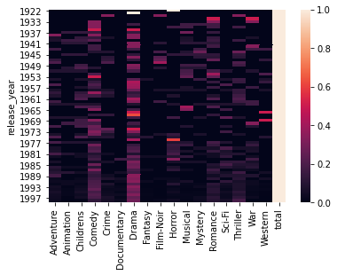

```python
#your code here

#dataframe with release year as index and genre is the column name
item_copy5 = item_copy3.copy()
item_copy5.rename(columns = {"release date" : "release_date"}, inplace =True)
item_copy5['release_year'] = item_copy5.release_date.str[-4:]
item_copy5.drop(['movie title', 'movie id','release_date', 'unknown'], axis =1, inplace = True)
item_copy5 = pd.pivot_table(item_copy5, index =["release_year"], values = ["Action","Adventure", "Animation", "Childrens",'Comedy','Crime', 'Documentary', 'Drama', 'Fantasy', 'Film-Noir', 'Horror','Musical', 'Mystery', 'Romance', 'Sci-Fi', "Thriller", 'War','Western' ], aggfunc='sum')


#total number of movies per year added to df
item_copy5["total"] = item_copy5.iloc[:,1:18].sum(axis = 1)

#item_copy5.loc['Column_Total']= item_copy5.sum(numeric_only=True, axis=0)
item_popular = item_copy5.iloc[:, 1:].div(item_copy5.total, axis = 0)


#plot the data
sns.heatmap(item_popular)
```

**Insights:** Dramas have been very volatile over the years. Documentaries are overall not that popular compared to the other categories.

### 9. Find the top 25 movies in terms of average ratings for movies that have been rated more than 100 times - 10 marks

Hints :

1. Find the count of ratings and average ratings for every movie.
2. Slice the movies which have ratings more than 100.
3. Sort values according to average rating such that movie which highest rating is on top.
4. Select top 25 movies.
5. You will have to use the .merge() function to get the movie titles.

Note: This question will need you to research about groupby and apply your findings. You can find more on groupby on https://realpython.com/pandas-groupby/.

```python
#your code here

# count the number of ratings by merging the data by movie id and make it a new dataframe

movie_counted = data.groupby("movie id")['user id'].count().reset_index(name = "count")
#this previous line shows us that there were 452 ratings for movie 1 and 131 rating for movie 2
movie_counted.sort_values("count", ascending = False, inplace =True)

##now, only choose movie ids that have more than 100 ratings
movies_334 = movie_counted.head(334)
movies_334 = movies_334.reset_index(drop = True)
movies_334

#now, find the average rating per movie
movie_average = data.groupby("movie id")["rating"].mean().reset_index(name = "average")
movie_average
#this previous line shows us the average rating per movie id. it reports that movie 1 was rated a 3.878 on average and movie 2 was rated 3.21 on average.
#now, i will sort the list so that the highest rate movies, on average, are on top
movie_average.sort_values("average", ascending = False, inplace = True)
movie_average = movie_average.reset_index(drop = True)
movie_average

#merge columns of previous 2 data sets

joined = pd.merge(movies_334,movie_average)
joined.head ()

#merge last dataset with movie names

popularity_contest = pd.merge(joined, item)
popularity_contest.head()

#sort the list with the highest rating is on top
popularity_contest.sort_values("average", ascending = False, inplace = True)
#re do the indexes
popularity_contest = popularity_contest.reset_index(drop = True)
popularity_contest.head (25)

#the output says that "A Close Shave" is the most popular movie with a rating of 4.49 and at least 100 reviews and the 25th most popular movie is "The Empire Strikes Back" with a rating of 4.20
```

|  | movie id | count | average | movie title | release date | unknown | Action | Adventure | Animation | Childrens | ... | Fantasy | Film-Noir | Horror | Musical | Mystery | Romance | Sci-Fi | Thriller | War | Western |
| --- | --- | --- | --- | --- | --- | --- | --- | --- | --- | --- | --- | --- | --- | --- | --- | --- | --- | --- | --- | --- | --- |
| 0 | 408 | 112 | 4.491071 | Close Shave, A | 28-Apr-1996 | 0 | 0 | 0 | 1 | 0 | ... | 0 | 0 | 0 | 0 | 0 | 0 | 0 | 1 | 0 | 0 |
| 1 | 318 | 298 | 4.466443 | Schindler's List | 01-Jan-1993 | 0 | 0 | 0 | 0 | 0 | ... | 0 | 0 | 0 | 0 | 0 | 0 | 0 | 0 | 1 | 0 |
| 2 | 169 | 118 | 4.466102 | Wrong Trousers, The | 01-Jan-1993 | 0 | 0 | 0 | 1 | 0 | ... | 0 | 0 | 0 | 0 | 0 | 0 | 0 | 0 | 0 | 0 |
| 3 | 483 | 243 | 4.456790 | Casablanca | 01-Jan-1942 | 0 | 0 | 0 | 0 | 0 | ... | 0 | 0 | 0 | 0 | 0 | 1 | 0 | 0 | 1 | 0 |
| 4 | 64 | 283 | 4.445230 | Shawshank Redemption, The | 01-Jan-1994 | 0 | 0 | 0 | 0 | 0 | ... | 0 | 0 | 0 | 0 | 0 | 0 | 0 | 0 | 0 | 0 |
| 5 | 603 | 209 | 4.387560 | Rear Window | 01-Jan-1954 | 0 | 0 | 0 | 0 | 0 | ... | 0 | 0 | 0 | 0 | 1 | 0 | 0 | 1 | 0 | 0 |
| 6 | 12 | 267 | 4.385768 | Usual Suspects, The | 14-Aug-1995 | 0 | 0 | 0 | 0 | 0 | ... | 0 | 0 | 0 | 0 | 0 | 0 | 0 | 1 | 0 | 0 |
| 7 | 50 | 583 | 4.358491 | Star Wars | 01-Jan-1977 | 0 | 1 | 1 | 0 | 0 | ... | 0 | 0 | 0 | 0 | 0 | 1 | 1 | 0 | 1 | 0 |
| 8 | 178 | 125 | 4.344000 | 12 Angry Men | 01-Jan-1957 | 0 | 0 | 0 | 0 | 0 | ... | 0 | 0 | 0 | 0 | 0 | 0 | 0 | 0 | 0 | 0 |
| 9 | 134 | 198 | 4.292929 | Citizen Kane | 01-Jan-1941 | 0 | 0 | 0 | 0 | 0 | ... | 0 | 0 | 0 | 0 | 0 | 0 | 0 | 0 | 0 | 0 |
| 10 | 427 | 219 | 4.292237 | To Kill a Mockingbird | 01-Jan-1962 | 0 | 0 | 0 | 0 | 0 | ... | 0 | 0 | 0 | 0 | 0 | 0 | 0 | 0 | 0 | 0 |
| 11 | 357 | 264 | 4.291667 | One Flew Over the Cuckoo's Nest | 01-Jan-1975 | 0 | 0 | 0 | 0 | 0 | ... | 0 | 0 | 0 | 0 | 0 | 0 | 0 | 0 | 0 | 0 |
| 12 | 98 | 390 | 4.289744 | Silence of the Lambs, The | 01-Jan-1991 | 0 | 0 | 0 | 0 | 0 | ... | 0 | 0 | 0 | 0 | 0 | 0 | 0 | 1 | 0 | 0 |
| 13 | 480 | 179 | 4.284916 | North by Northwest | 01-Jan-1959 | 0 | 0 | 0 | 0 | 0 | ... | 0 | 0 | 0 | 0 | 0 | 0 | 0 | 1 | 0 | 0 |
| 14 | 127 | 413 | 4.283293 | Godfather, The | 01-Jan-1972 | 0 | 1 | 0 | 0 | 0 | ... | 0 | 0 | 0 | 0 | 0 | 0 | 0 | 0 | 0 | 0 |
| 15 | 285 | 162 | 4.265432 | Secrets & Lies | 04-Oct-1996 | 0 | 0 | 0 | 0 | 0 | ... | 0 | 0 | 0 | 0 | 0 | 0 | 0 | 0 | 0 | 0 |
| 16 | 272 | 198 | 4.262626 | Good Will Hunting | 01-Jan-1997 | 0 | 0 | 0 | 0 | 0 | ... | 0 | 0 | 0 | 0 | 0 | 0 | 0 | 0 | 0 | 0 |
| 17 | 657 | 131 | 4.259542 | Manchurian Candidate, The | 01-Jan-1962 | 0 | 0 | 0 | 0 | 0 | ... | 0 | 1 | 0 | 0 | 0 | 0 | 0 | 1 | 0 | 0 |
| 18 | 474 | 194 | 4.252577 | Dr. Strangelove or: How I Learned to Stop Worr... | 01-Jan-1963 | 0 | 0 | 0 | 0 | 0 | ... | 0 | 0 | 0 | 0 | 0 | 0 | 1 | 0 | 1 | 0 |
| 19 | 174 | 420 | 4.252381 | Raiders of the Lost Ark | 01-Jan-1981 | 0 | 1 | 1 | 0 | 0 | ... | 0 | 0 | 0 | 0 | 0 | 0 | 0 | 0 | 0 | 0 |
| 20 | 479 | 179 | 4.251397 | Vertigo | 01-Jan-1958 | 0 | 0 | 0 | 0 | 0 | ... | 0 | 0 | 0 | 0 | 1 | 0 | 0 | 1 | 0 | 0 |
| 21 | 313 | 350 | 4.245714 | Titanic | 01-Jan-1997 | 0 | 1 | 0 | 0 | 0 | ... | 0 | 0 | 0 | 0 | 0 | 1 | 0 | 0 | 0 | 0 |
| 22 | 511 | 173 | 4.231214 | Lawrence of Arabia | 01-Jan-1962 | 0 | 0 | 1 | 0 | 0 | ... | 0 | 0 | 0 | 0 | 0 | 0 | 0 | 0 | 1 | 0 |
| 23 | 484 | 138 | 4.210145 | Maltese Falcon, The | 01-Jan-1941 | 0 | 0 | 0 | 0 | 0 | ... | 0 | 1 | 0 | 0 | 1 | 0 | 0 | 0 | 0 | 0 |
| 24 | 172 | 367 | 4.204360 | Empire Strikes Back, The | 01-Jan-1980 | 0 | 1 | 1 | 0 | 0 | ... | 0 | 0 | 0 | 0 | 0 | 1 | 1 | 0 | 1 | 0 |

25 rows × 24 columns

### 10. Check for the validity of the below statements with respect to the data provided - 10 marks

- Men watch more drama than women
- Women watch more Sci-Fi than men
- Men watch more Romance than women

**compare the percentages**

**Please pay attention to what should be the denominator while calculating percentages**

1. Merge all the datasets
2. There is no need to conduct statistical tests around this. Just **compare the percentages** and comment on the validity of the above statements.
3. you might want ot use the .sum(), .div() function here.
4. Use number of ratings to validate the numbers. For example, if out of 4000 ratings received by women, 3000 are for drama, we will assume that 75% of the women watch drama.

```python
#your code here

###do men watch more drama than women?

#merge dataset to see gender of user
user_to_id = pd.merge(user, data)
user_to_id
#25740 females are in the data and 74260 men are in the data
user_to_id.drop (['occupation', 'zip code', 'timestamp','age', 'rating' ], axis =1, inplace = True)
total_df = pd.merge (user_to_id, item)
total_df.groupby(["Drama", 'gender'])['movie id'].count()
# from this grouby, we see that 10794/(10794+14406) = 0.42 or 42% of women watch dramas
# and 28324/(44598+28324) = 0.39 or 39% of men watch drama
##therefore, women watch more drama than men

###do women watch more sci-fi than men?

total_df.groupby(["Sci-Fi", 'gender'])['movie id'].count()
#from this groupby we see that 2619/(22581+2619) = 0.10 or 10% of sci Fi was watched by women
# and 10042/(10042+62880) = 0.14 or 14% of sci fi was watched by the men
## therefore, more men than women watch sci-fi


###do women watch more romance than men?

total_df.groupby(["gender", 'Romance'])['movie id'].count()
#from this groupby we see that 5665/(5665+19535) = 0.22 or 22% of romance was watched by women
# and 13134/(59788+13134) = 0.18 or 18% of romance was watched by men
##therefore, more women watch romance than men
```

```
gender  Romance
F       0          19535
        1           5665
M       0          59788
        1          13134
Name: movie id, dtype: int64
```

**Conclusion:**

## women watch more drama than men

## more men than women watch sci-fi

## more women watch romance than men